# Penguins - Correlation Matrix

#### Outcomes covered in the below work

- 4.5 Concept of correlation and correlation matrices
- 4.8 Documenting analyses

```r
library(tidyverse)
library(palmerpenguins)
```

```r
library(ggplot2)
library(GGally)
# install.packages("palmerpenguins")
penguins <- palmerpenguins::penguins
glimpse(penguins)
```

```
## Rows: 344
## Columns: 8
## $ species           <fct> Adelie, Adelie, Adelie, Adelie, Adelie, Adelie, Adel~
## $ island            <fct> Torgersen, Torgersen, Torgersen, Torgersen, Torgerse~
## $ bill_length_mm    <dbl> 39.1, 39.5, 40.3, NA, 36.7, 39.3, 38.9, 39.2, 34.1, ~
## $ bill_depth_mm     <dbl> 18.7, 17.4, 18.0, NA, 19.3, 20.6, 17.8, 19.6, 18.1, ~
## $ flipper_length_mm <int> 181, 186, 195, NA, 193, 190, 181, 195, 193, 190, 186~
## $ body_mass_g       <int> 3750, 3800, 3250, NA, 3450, 3650, 3625, 4675, 3475, ~
## $ sex               <fct> male, female, female, NA, female, male, female, male~
## $ year              <int> 2007, 2007, 2007, 2007, 2007, 2007, 2007, 2007, 2007~
```

### The correlation matrix

A correlation matrix that shows the correlation between bill length, bill depth, flipper length, and body mass across species:

(Total of each = Adelie: 151, Chinstrap: 68, Gentoo: 123)

```r
# selecting appropriate columns and dropping the 2 penguins with NA under all
# of their records
penguins_correlation <- penguins %>%
  select(species,
         bill_length_mm,
         bill_depth_mm,
         flipper_length_mm,
         body_mass_g) %>%
  drop_na()
```

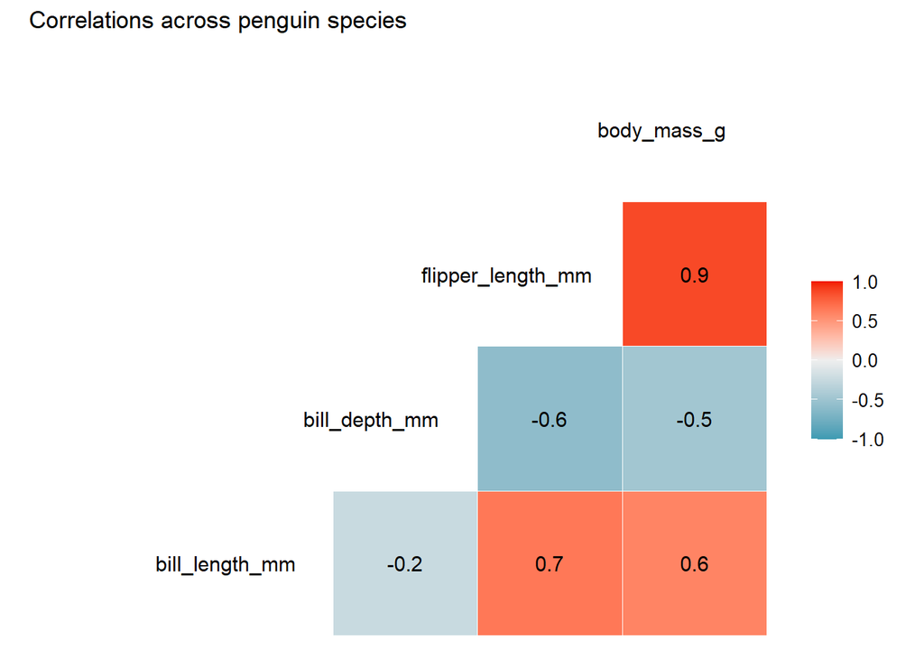

```r
ggcorr(penguins_correlation,
       method = c("everything", "pearson"),
       hjust = 0.75,
       size = 4,
       layout.exp = 1,
       legend.size = 10,
       label = TRUE,
       label_size = 4) +
  labs(title = "Correlations across penguin species")
```

It is first important to note that the data should be visualised before trusting the correlation coefficients above.

The correlation matrix above shows that body mass and flipper length are the most strongly correlated of all the relationships. As we can see a *very strong* positive correlation (r = 0.9), it may be very likely that penguins with a larger mass have longer flipper lengths. Further *strong*, positive, correlations can be seen between body mass and bill length (r = 0.6) and between flipper length and bill length (r = 0.7).

Negative correlations can also be seen here. There is a *weak* negative correlation between bill depth and bill length (-0.2) meaning that as one decreases in size the other may increase. A *moderate* negative correlation can be seen between body mass and bill depth (r = -0.5) again meaning that as one decreases the other may increase. Finally, a *strong* negative correlation can be seen between flipper length and bill depth (r = -0.6) meaning that penguins with longer flippers may be more likely to have shorter bill depths and vice versa.

Therefore, (to take one example) it may be the case that the larger the mass of a penguin, the longer the flipper length and bill length, but the shorter the bill depth.